# 260-2017-02-17

2017-02-15 08:39:50

## Today's Topics

- **Quiz 2**.
- Review Exam 1

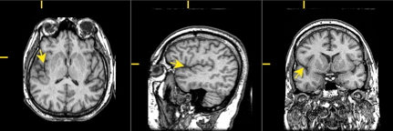

## Question 12: What fissure or sulcus is represented in the figures?

- Superior temporal sulcus
- Central sulcus
- Longitudinal fissure
- Lateral fissure

## Question 12: What fissure or sulcus is represented in the figures?

- Superior temporal sulcus
- Central sulcus Not dividing frontal/parietal; not vertical
- Longitudinal fissure Not medial; not dividing hemispheres
- Lateral fissure

## Question 13: Primary somatosensory cortex (SI) is found in the ????.

- Temporal lobe
- Frontal lobe
- Hypothalamus
- Basal ganglia
- Parietal lobe

## Question 13: Primary somatosensory cortex (SI) is found in the ????.

- Temporal lobe
- Frontal lobe
- Hypothalamus
- Basal ganglia
- Parietal lobe

## Study hint

- Cortical landmarks https://psu-psychology.github.io/psych-260-spring-2017/lecture-notes/260-2017-01-30.html#22
- Lobes, landmarks, areas https://psu-psychology.github.io/psych-260-spring-2017/lecture-notes/260-2017-01-30.html#46

## Question 16:

Your grandmother has a stroke. The neurologist chooses an X-ray-based structural brain imaging method that gives satisfactory, but not especially detailed spatial resolution. What method is that?

- Computed tomography (CT)
- functional MRI.
- Positron Emission Tomography (PET).
- Anterograde tract tracers.

## Question 16:

Your grandmother has a stroke. The neurologist chooses an X-ray-based structural brain imaging method that gives satisfactory, but not especially detailed spatial resolution. What method is that?

- Computed tomography (CT)
- functional MRI Not X-ray based
- Positron Emission Tomography (PET) Not X-ray based
- Anterograde tract tracers Cell projection method

## Question 20: Among other functions ???? play(s) a role in regulating the extracellular concentration of ????.

- astrocytes; glutamate
- myelin sheath; Na+ ions.
- Circle of Willis; blood loss.
- blood/brain barrier; oxygen levels.

## Question 20: Among other functions ???? play(s) a role in regulating the extracellular concentration of ????.

- astrocytes; glutamate
- myelin sheath; Na+ ions.
- Circle of Willis; blood loss.
- blood/brain barrier; oxygen levels.

## Question 31: Which of the following marks the medial boundary of the frontal lobe?

- Lateral fissure
- Longitudinal fissure
- Central sulcus
- Inferior temporal gyrus

[interactive chart not shown]

## Question 31: Which of the following marks the medial boundary of the frontal lobe?

- Lateral fissure
- Longitudinal fissure
- Central sulcus
- Inferior temporal gyrus

## Question 43:

In a typical neuron near or slightly above its resting potential chloride (Cl-) ions would flow ???? following the concentration gradient. This would move the neuron ???? its firing threshold.

- Inward; farther from
- Inward; closer to
- Outward; farther from
- Outward; closer to

## Question 43:

In a typical neuron near or slightly above its resting potential chloride (Cl-) ions would flow ???? following the concentration gradient. This would move the neuron ???? its firing threshold.

- Inward; farther from
- Inward; closer to
- Outward; farther from
- Outward; closer to